# astropy_saao slides

[figure not shown]

## Steve Crawford

(one small member of the much larger astropy community)

## Philosopy of Astropy

## Contributors of Astropy

## Astropy v0.4 and affiliate packages

## How to Contribute

# History and Motivation

# Philosophy of Astropy

## The Astropy Project is a community effort to develop a **core package for Astronomy in Python and foster interoperability** between Python astronomy packages.

Minimize duplication

Provide a well-documented and well-tested core astronomy library

Create frameworks for producing astronomy related code

Build Community consensus

# Contributors to Astropy

## Astropy has organically grown from the astropy@scipy.org mailing list

## Astropy has over 90 contributors from around the world

## Project Coordinators

### Perry Greenfield

### Thomas Robitaille

### Erik Tollerud

### Astropy on Github

[figure not shown]

# Astropy Core

## v0.4.2

Only has Numpy as a required dependency (easy to install)

Well tested, documented, and stable code

Works on Linux, MacOS X, and Windows

Python 2 and 3 compatible

Latest stable release v0.4.2 on Sept 23

### Core data structures and transformations

Constants

Units and Quantities

N-dimensional datasets

Data Tables

Time and Dates

Astronomical Coordinate Systems

World Coordinate System

Models and Fitting

### Connecting up: Files and I/O

Unified file read/write interface

FITS File handling

ASCII Tables

VOTable XML handling

Miscellaneous Input/Output

### Astronomy computations and utilities

Convolution and filtering

Cosmological Calculations

Astrostatistics Tools

Virtual Observatory Access

## Analysis with Units

```python
from astropy import constants as c
c.G
```

$6.67384\times 10^{-11} \; \mathrm{\frac{m^{3}}{kg\,s^{2}}}$

```python
M = c.M_earth
M
```

$5.9742\times 10^{+24} \; \mathrm{kg}$

```python
from astropy import units as u
r = c.R_earth
v_esc = (2 * c.G * M / r)**0.5
v_esc.to(u.km/u.s)
```

$11.1814 \; \mathrm{\frac{km}{s}}$

```python
v_esc = ((2 * c.G * M / (r+559*u.km))**0.5)
v_esc.to(u.km/u.s)
```

$10.7214 \; \mathrm{\frac{km}{s}}$

```python
v_esc = ((2 * c.G * 3 * u.kg / (r+559*u.km))**0.5)
v_esc.to(u.km/u.s)
```

$7.59755\times 10^{-12} \; \mathrm{\frac{km}{s}}$

## Using Coordinates

```python
from astropy import units as u
from astropy.coordinates import SkyCoord
c1 = SkyCoord('00h42m00s', '+41d12m00s', 'icrs')
```

```python
print("{0} {1}".format( c1.ra,c1.dec))
```

```
10.5 deg 41.2 deg
```

```python
print c1.to_string('hmsdms')
```

```
00h42m00s +41d12m00s
```

```python
c2 = SkyCoord(ra=11*u.degree, dec=10*u.degree, distance=11.5*u.pc, frame='icrs')
c1.separation(c2)
```

$31^\circ12{}^\prime11.2337{}^{\prime\prime}$

Also available are coordinate transformation between different systems (e.g. ICRS, FK5, galactic) and matching catalags of coordinates.

## Modeling

Astropy also has a modelling fitting package. Let's see how it works. Let's create a Gaussian shape and add some noise to it.

```python
import numpy as np
x = np.linspace(-5., 5., 200)
y = 3 * np.exp(-0.5 * (x - 1.3)**2 / 0.8**2)
y += np.random.normal(0., 0.2, x.shape)
```

Now let's fit the model using the astropy modeling class

```python
from astropy.modeling import models, fitting
g_init = models.Gaussian1D(amplitude=1., mean=0, stddev=1.)
fit_g = fitting.LevMarLSQFitter()
g = fit_g(g_init, x, y)
print(g)
```

```
Model: Gaussian1D
Inputs: 1
Outputs: 1
Model set size: 1
Parameters:
      amplitude        mean         stddev
    ------------- ------------- --------------
    3.02399793382 1.29056666017 0.806526854961
```

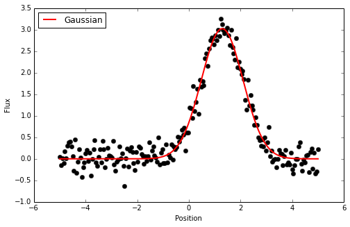

```python
import pylab as plt
plt.figure(figsize=(8,5))
plt.plot(x, y, 'ko')
plt.plot(x, g(x), 'r-', lw=2, label='Gaussian')
plt.xlabel('Position')
plt.ylabel('Flux')
plt.legend(loc=2)
plt.show()
```

A range of different models already exist for 1-D and 2-D fitting. The API for the modeling class is still being refined but it should be stable in the next major release.

In addition to what has been shown so far, a number of core data structures and transformations have been included here to help build and coordinate other packages. These include:

- Quantity: An object with a value and unit
- Table: functionality for storing and manipulating heterogeneous tables of data
- NDData: A general astronomical data object including data, meta, uncertainty, wcs
- Time: functionality for manipulating astronomical relevant times and dates
- WCS: World Coordinate Systems

## Accessing Data

Tools for accessing the virtual observatory

```python
from astropy.vo.client import conesearch
```

Tools for reading/writing FITS files (formerly pyfits)

```python
from astropy.io import fits
```

Tools for reading in ascii tables including CDS, IPAC, HTML, Latex, Sextractor

```python
from astropy.io import ascii
table = ascii.read("ftp://cdsarc.u-strasbg.fr/pub/cats/VII/253/snrs.dat",
                   readme="ftp://cdsarc.u-strasbg.fr/pub/cats/VII/253/ReadMe")
```

```
Downloading ftp://cdsarc.u-strasbg.fr/pub/cats/VII/253/snrs.dat [Done]
Downloading ftp://cdsarc.u-strasbg.fr/pub/cats/VII/253/ReadMe [Done]
```

```python
print table
```

```
    SNR     RAh RAm RAs ... u_S(1GHz) Sp-Index u_Sp-Index         Names
             h  min  s  ...
----------- --- --- --- ... --------- -------- ---------- ---------------------
G000.0+00.0  17  45  44 ...         ?      0.8          ?            Sgr A East
G000.3+00.0  17  46  15 ...        --      0.6         --                    --
G000.9+00.1  17  47  21 ...         ?       --          v                    --
G001.0-00.1  17  48  30 ...        --      0.6          ?                    --
G001.4-00.1  17  49  39 ...         ?       --          ?                    --
G001.9+00.3  17  48  45 ...        --      0.6         --                    --
G003.7-00.2  17  55  26 ...        --     0.65         --                    --
G003.8+00.3  17  52  55 ...         ?      0.6         --                    --
G004.2-03.5  18   8  55 ...         ?      0.6          ?                    --
G004.5+06.8  17  30  42 ...        --     0.64         -- Kepler, SN1604, 3C358
G004.8+06.2  17  33  25 ...        --      0.6         --                    --
        ... ... ... ... ...       ...      ...        ...                   ...
G356.3-00.3  17  37  56 ...         ?       --          ?                    --
G356.3-01.5  17  42  35 ...         ?       --          ?                    --
G357.7-00.1  17  40  29 ...        --      0.4         --             MSH 17-39
G357.7+00.3  17  38  35 ...        --      0.4          ?                    --
G358.0+03.8  17  26   0 ...         ?       --          ?                    --
G358.1+00.1  17  37   0 ...         ?       --          ?                    --
G358.5-00.9  17  46  10 ...         ?       --          ?                    --
G359.0-00.9  17  46  50 ...        --      0.5         --                    --
G359.1-00.5  17  45  30 ...        --      0.4          ?                    --
G359.1+00.9  17  39  36 ...         ?       --          ?                    --
```

## Cosmology in Astropy

```python
from astropy.cosmology import WMAP9 as cosmo
cosmo.H(0)
```

$69.32 \; \mathrm{\frac{km}{Mpc\,s}}$

```python
cosmo
```

```
FlatLambdaCDM(name="WMAP9", H0=69.3 km / (Mpc s), Om0=0.286, Tcmb0=2.725 K, Neff=3.04, m_nu=[ 0.  0.  0.] eV, Ob0=0.0463)
```

A number of cosmological models are already available and the user can define their own cosmological models including dark energy and neutrino properties

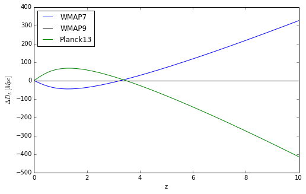

```python
from astropy.cosmology import WMAP7
from astropy.cosmology import WMAP9 as cosmo
from astropy.cosmology import Planck13

z = np.linspace(0,10,200)

plt.figure(figsize=(8,5))
plt.plot(z, WMAP7.luminosity_distance(z)-cosmo.luminosity_distance(z), 'b-', label='WMAP7')
plt.plot(z, cosmo.luminosity_distance(z)-cosmo.luminosity_distance(z), '-', color='black', label='WMAP9')
plt.plot(z, Planck13.luminosity_distance(z)-cosmo.luminosity_distance(z), 'g-', label='Planck13')
plt.xlabel('z')
plt.ylabel('$\Delta D_L [%s]$' % cosmo.luminosity_distance(0).unit)
plt.legend(loc=2)
plt.show()
```

## Useful statistics for Astronomy

```python
from astropy import stats
for x in stats.funcs.__all__: print x
```

```
sigma_clip
binom_conf_interval
binned_binom_proportion
median_absolute_deviation
biweight_location
biweight_midvariance
signal_to_noise_oir_ccd
bootstrap
```

# Astropy Framework

Development of testing, documentation, and installation infrastructre to make it easier to build and deploy your own code

## Package Template

[figure not shown]

# Astropy Affiliated Packages

## Astropy Affiliated Packages

- [APLpy](http://aplpy.github.io)
- [astroML](http://astroml.github.com/)
- [astropysics](http://packages.python.org/Astropysics/)
- astroquery
- ccdproc
- gammapy
- ginga
- [montage-wrapper](http://www.astropy.org/montage-wrapper/)
- photutils
- pydl
- pyvo
- [sncosmo](https://sncosmo.github.io)
- specutils

These packages are at different stages of development and there are a number of other packages in early development which are not mentioned here. Some of the packages will be integrated into the core astropy package.

### APLPY

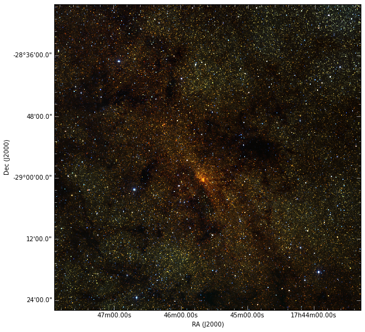

```python
import aplpy
gc = aplpy.FITSFigure('2MASS_k.fits')
gc.show_rgb('2MASS_arcsinh_color.png')
```

### astroquery

```python
from astroquery.simbad import Simbad
result_table = Simbad.query_object("m1")
result_table.pprint(show_unit=True)
```

```
MAIN_ID      RA         DEC     ... COO_QUAL COO_WAVELENGTH     COO_BIBCODE
          "h:m:s"     "d:m:s"   ...
------- ----------- ----------- ... -------- -------------- -------------------
  M   1 05 34 31.94 +22 00 52.2 ...        C              R 2011A&A...533A..10L
```

Services available to query include Vizier, Simbad, NED, SDSS, GAMA, archives, catalogs, and many more online resources

### ccdproc

```python
import ccdproc
ccd = ccdproc.CCDData.read('a8280418.fits', unit=u.adu)
ccd.header
```

```
SIMPLE  =                    T         /
BITPIX  =                  -32
NAXIS   =                    2         /
NAXIS1  =                  536         / columns
NAXIS2  =                  520         / rows
OBSERVAT= 'SAAO    '                   / observatory source
TELESCOP= 'SAAO 1.0m'                  /
OBSERVER= 'crawford                  ' / observer
INSTRUME= 'STE3 CCD'                   /
DATE-OBS= '2013-07-17'                 / UT date
OBJECT  = 'rs0037                    ' /
IMAGETYP= 'object    '                 / IRAF image type
FILTERS =                   82         / Filters 10*A+B
RA      = ' 00:39:35'                  / ra
DEC     = ' 00:51:36'                  / dec
RA_OBS  =               9.8958         / ra in degrees
DEC_OBS =              +0.8600         / dec in degrees
EPOCH   =               2000.0         / Equinox of RA,Dec
UT      = '04:00:58'                   / UT at Exposure start
ST      = '01:04:47'                   / Siderial time at Start exp
MJD-OBS =          56490.16734         / JD-2400000.5 at Start exp
EXPTIME =              300.037         / integration time in secs
SECZ    =                1.202         / Air mass at start exp
TRIMSEC =  '[  17: 528,   1: 520]'     / Useful part of data
BIASSEC =  '[   4:  13,   1: 520]'     / Overscan region
GAIN    =                  1.9         / e-/ADU
RDNOISE =                  5.0         / e-(rms) read noise
CCD-TEMP=                180.0         / CCD Cu block temperature
COMMENT =
```

```python
ccd = ccdproc.subtract_overscan(ccd, fits_section=ccd.header['biassec'],
                                median=True, model=models.Polynomial1D(5))
ccd = ccdproc.trim_image(ccd, fits_section=ccd.header['trimsec'])
ccd = ccdproc.create_deviation(ccd, readnoise=ccd.header['rdnoise']*u.electron,
                              gain=ccd.header['gain']*u.electron/u.adu)
ccd.write('out.fits', clobber=True)
```

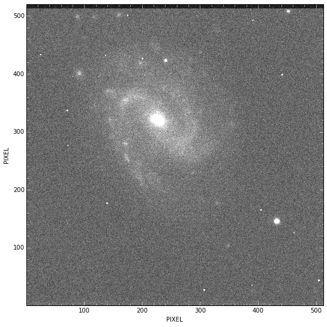

```python
fc = aplpy.FITSFigure(ccd.data)
fc.show_grayscale()
```

# How to get involved

Download and install astropy

Join astropy@scipy.org

Provide feedback (submit issues, ask questions)

Use the astropy template and astropy classes for your packages

Look for 'easy' issues and submit a pull request

Contribute code either to astropy or an affiliated package

# Astropy Resources

Websites  
Homepage: http://www.astropy.org/  
Documentation: http://docs.astropy.org/  
Tutorials: http://www.astropy.org/astropy-tutorials/

Github  
https://github.com/astropy

Contacts  
Twitter: [@astropy](https://twitter.com/astropy)  
General Mailing List: [astropy@scipy.org](http://mail.scipy.org/mailman/listinfo/astropy)  
Mailing list for developers: [astropy-dev@googlegroups.com](https://groups.google.com/d/forum/astropy-dev)

Reference  
['Astropy: A community Python package for astronomy', Astropy Collaboration et al. 2013, Astronomy and Astrophysics, 558, AA33](http://adsabs.harvard.edu/abs/2013A%26A...558A..33A)

Acknowledgement  
This talk made use of Astropy, a community-developed core Python package for Astronomy (Astropy Collaboration, 2013).

Special thank you to Thomas Robitaille, Adrian Price-Whelan, Mathew Craig, and the Astropy Community for material for this talk.